# Análise Multivariada

19 de julho de 2025

## Conjunto de Dados `druguse`

- Pesquisa sobre uso regular de substâncias psicoativas (lícitas e ilícitas), com dados de taxas de uso coletados entre 1.634 estudantes, do 7º ao 9º series, em 11 escolas, na região metropolitana de Los Angeles.
- Substâncias pesquisadas: `cigarettes`, `beer`, `wine`, `liquor`, `cocaine`, `tranquillizers`, `drug store medications used to get high`, `heroin and other opiates`, `marijuana`, `hashish`, `inhalants (glue, gasoline, etc.)`, `hallucinogenics (LSD, mescaline, etc.)`, `amphetamine stimulants`.
- Escala de medidas: `nunca tentei`, `uma vez`, `algumas vezes`, `muitas vezes` e `regularmente`.

**Fonte**: EVERITT, B. HOTHORN, T. *An introduction to applied multivariate analysis with R*. New York, NY: Springer, 2011.

## Matriz de Correlações Amostrais

O conjunto de dados com as 1.634 observações multivariadas (13 variáveis) não está disponível.

A matriz de correlações amostrais é obtida pelo importação do script `chap4druguse.dat`:

```r
source("https://raw.githubusercontent.com/Bessegato/Disciplinas/main/Dados/chap4druguse.dat")
R <- druguse.cor
```

```
##       [,1] [,2] [,3] [,4] [,5] [,6] [,7] [,8] [,9] [,10] [,11] [,12] [,13]
##  [1,] 1.00 0.45 0.42 0.44 0.11 0.20 0.09 0.08 0.51  0.30  0.24  0.10  0.24
##  [2,] 0.45 1.00 0.62 0.60 0.07 0.15 0.10 0.06 0.44  0.32  0.20  0.09  0.20
##  [3,] 0.42 0.62 1.00 0.58 0.05 0.14 0.11 0.07 0.36  0.24  0.18  0.07  0.18
##  [4,] 0.44 0.60 0.58 1.00 0.12 0.26 0.12 0.10 0.48  0.37  0.26  0.14  0.29
##  [5,] 0.11 0.07 0.05 0.12 1.00 0.35 0.21 0.32 0.19  0.30  0.27  0.28  0.28
##  [6,] 0.20 0.15 0.14 0.26 0.35 1.00 0.22 0.36 0.32  0.38  0.32  0.37  0.54
##  [7,] 0.09 0.10 0.11 0.12 0.21 0.22 1.00 0.20 0.15  0.16  0.31  0.23  0.23
##  [8,] 0.08 0.06 0.07 0.10 0.32 0.36 0.20 1.00 0.15  0.22  0.29  0.32  0.31
##  [9,] 0.51 0.44 0.36 0.48 0.19 0.32 0.15 0.15 1.00  0.53  0.30  0.20  0.39
## [10,] 0.30 0.32 0.24 0.37 0.30 0.38 0.16 0.22 0.53  1.00  0.30  0.37  0.47
## [11,] 0.24 0.20 0.18 0.26 0.27 0.32 0.31 0.29 0.30  0.30  1.00  0.34  0.39
## [12,] 0.10 0.09 0.07 0.14 0.28 0.37 0.23 0.32 0.20  0.37  0.30  1.00  0.51
## [13,] 0.24 0.20 0.18 0.29 0.28 0.54 0.23 0.31 0.39  0.47  0.39  0.51  1.00
```

## *Correlation Plot* de R

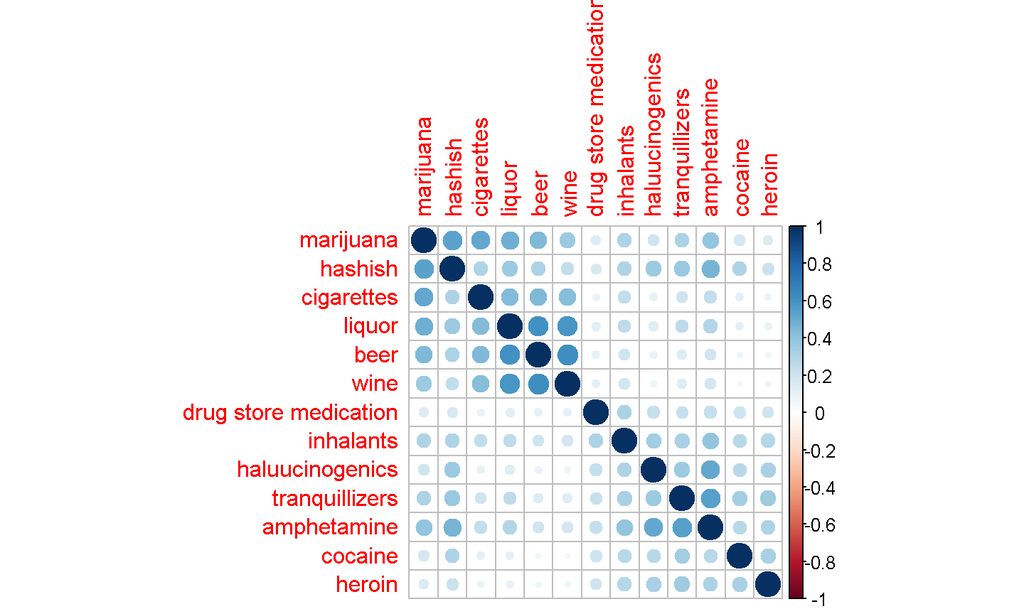

- marijuana, hashish, cigarettes
- liquor, beer wine
- halucinogenis, tranquilizers, amphetamine
- demais sem agrupamentos claros
- A interpretação do correlograma é exploratória
- Os agrupamentos deverão surgir separadamente nos fatores.

## *Correlation Network Plot* de R

### Grafo das correlações em R

[figure not shown]

## *Correlation Network Plot* de R

### Código do Grafo de R

```r
library(tidyverse); library(corrr); library(igraph); library(ggraph)
  # Criação de tidy data frame
tidy_cors <- R %>%
    as_cordf() %>%
    stretch()

  # Converter correlações mais fortes que algum valor
  # para um objeto gráfico não direcionado
graph_cors <- tidy_cors %>%
  filter(abs(r) > .4) %>%
  graph_from_data_frame(directed = FALSE)

  #Plot
ggraph(graph_cors) +
  geom_edge_link(aes(edge_alpha = abs(r), edge_width = abs(r), color = r)) +
  guides(edge_alpha = "none", edge_width = "none") +
  scale_edge_colour_gradientn(limits = c(-1, 1), colors = c("firebrick2", "dodgerblue2")) +
  geom_node_point(color = "white", size = 5) +
  geom_node_text(aes(label = name), repel = TRUE) +
  theme_graph() +
  labs(title = "Correlações entre as variáveis")
```

## Teste de Esfericidade de Bartlett

```r
psych::cortest.bartlett(R, n = 1634)$p.value
```

```
## [1] 0
```

- \(H_0\): R é matriz identidade

## Teste de *Kaiser-Meyer-Olkin*

```r
det(R)
psych::KMO(R)
```

[output not shown]

- Testa se a matriz é fatorizável (se as correlações são significativas)

## Número de Fatores

### Teste de Máxima Verossimilhança

```r
sapply(1:6, function(nf) factanal(covmat = R, factors = nf, method = "mle",
                                  n.obs = 1634)$PVAL)
```

```
##    objective    objective    objective    objective    objective    objective
## 0.000000e+00 1.343854e-69 4.123785e-28 4.899118e-11 3.160632e-05 6.558653e-02
```

- Os valores sugerem que apenas a solução com 6 fatores oferece um ajuste adequado
- O teste baseia-se em normalidade multivariada e é conservativo.

## Modelo Fatorial Ortogonal

### 6 fatores (Varimax)

```
##
## Loadings:
##                       Factor1 Factor2 Factor3 Factor4 Factor5 Factor6
## cigarettes             0.494                           0.411
## beer                   0.775                           0.113
## wine                   0.785
## liquor                 0.721   0.123   0.105   0.115   0.162
## cocaine                        0.519           0.132           0.159
## tranquillizers         0.131   0.563   0.321   0.103   0.144
## drug store medication          0.248                           0.424
## heroin                         0.540   0.101                   0.179
## marijuana              0.428   0.160   0.154   0.260   0.606   0.103
## hashish                0.244   0.281   0.190   0.877   0.195
## inhalants              0.171   0.324   0.165           0.149   0.465
## haluucinogenics                0.401   0.344   0.186           0.231
## amphetamine            0.151   0.341   0.888   0.141   0.139   0.166
##
##                Factor1 Factor2 Factor3 Factor4 Factor5 Factor6
## SS loadings      2.301   1.448   1.133   0.956   0.680   0.584
## Proportion Var   0.177   0.111   0.087   0.074   0.052   0.045
## Cumulative Var   0.177   0.288   0.376   0.449   0.501   0.546
```

## Modelo Fatorial Ortogonal - 6 Fatores

### Interpretação

- Fator 1: `wine` (0.786), `beer` (0.776), `liquor` (0.720), `cigarettes` (0.494) e`marijuana` (0.429)
  - Uso social (*soft drug use*)
- Fator 2: `tranquillizers` (0.563), `heroin` (0.540) e `cocaine` (0.519)
  - Uso pesado (*hard drug use*)
- Fator 3: amphetamine (0.888)
  - Uso de anfetamina
- Fator 4: hashish (0.877)
  - Uso de haxixe

## Rotações

Pacote `GPArotation`

- Ortogonais:
  - `varimax`
  - `quartimax`
  - `equamax`
- Oblíquas:
  - `oblimin`
  - `promax`

## Modelo Fatorial Oblíquo

### 6 fatores (oblimin) - Cargas de Padrão

```
##
## Loadings:
##                       Factor1 Factor2 Factor3 Factor4 Factor5 Factor6
## cigarettes             0.221                           0.523
## beer                   0.744
## wine                   0.838
## liquor                 0.653                           0.117
## cocaine                       -0.109   0.101   0.506
## tranquillizers                 0.214           0.532
## drug store medication                                          0.491
## heroin                                         0.534           0.114
## marijuana                                              0.754
## hashish                                0.985
## inhalants                                              0.126   0.504
## haluucinogenics                0.294   0.167   0.199  -0.132   0.174
## amphetamine                    0.983
##
##             Factor1 Factor2 Factor3 Factor4 Factor5 Factor6
## SS loadings   1.869   1.259   1.115   1.077   1.065   0.718
```

## Modelo Fatorial Oblíquo

```r
estrutura <- attr(mfob6$loadings, "covariance")
rownames(estrutura) <- paste0("F", 1:6) -> colnames(estrutura)
estrutura
```

```
##           F1        F2        F3        F4        F5        F6
## F1 1.0000000 0.2400110 0.3355892 0.1334163 0.6473010 0.2573943
## F2 0.2400110 1.0000000 0.4549584 0.5812344 0.3882876 0.4415252
## F3 0.3355892 0.4549584 1.0000000 0.4414590 0.5503439 0.3303092
## F4 0.1334163 0.5812344 0.4414590 1.0000000 0.2777829 0.6362251
## F5 0.6473010 0.3882876 0.5503439 0.2777829 1.0000000 0.2961132
## F6 0.2573943 0.4415252 0.3303092 0.6362251 0.2961132 1.0000000
```

## Número de Fatores

### *Scree Plot* e Variância Explicada

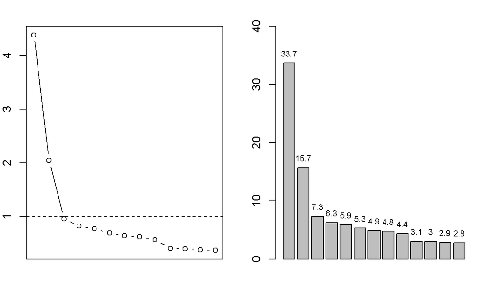

A porcentagem acumulada em cada autovalor é:

```
##  [1]  33.68589  49.40597  56.74397  63.01618  68.91368  74.21841  79.10688
##  [8]  83.86436  88.22853  91.29931  94.33225  97.21045 100.00000
```

## Quantidade de Fatores

- Interpretação modelo de 6 fatores
- Correlação entre fatores
- Sugestão do scree plot
- Ajustar modelos de 3 e de 4 fatores

## Modelo Fatorial Ortogonal

### 3 Fatores - Comunalidades

```r
nf <-3
mfor3 <- factanal(covmat = R, factors = nf, method = "mle", rotation = "varimax",
                  n.obs = 1634)
```

- Comunalidades

```
##            cigarettes                  beer                  wine
##             0.3859983             0.6343414             0.6169114
##                liquor               cocaine        tranquillizers
##             0.5883681             0.2301807             0.4523566
## drug store medication                heroin             marijuana
##             0.1340387             0.2538837             0.8651558
##               hashish             inhalants       haluucinogenics
##             0.4483832             0.2899566             0.4084710
##           amphetamine
##             0.5673143
```

## Modelo Fatorial Ortogonal

### 4 Fatores - Comunalidades

```r
nf <-4
mfor4 <- factanal(covmat = R, factors = nf, method = "mle", rotation = "varimax",
                  n.obs = 1634)
```

- Comunalidades

```
##            cigarettes                  beer                  wine
##             0.3822206             0.6355340             0.6140910
##                liquor               cocaine        tranquillizers
##             0.5871479             0.3302457             0.4286112
## drug store medication                heroin             marijuana
##             0.1603195             0.3127310             0.9016464
##               hashish             inhalants       haluucinogenics
##             0.4318302             0.3060900             0.3676710
##           amphetamine
##             0.9803158
```

## Modelo Fatorial Ortogonal

### Comunalidades e Especificidades

|  | 3 Fatores Comunalidade | 3 Fatores Específica | 4 Fatores Comunalidade | 4 Fatores Específica | 6 Fatores Comunalidade | 6 Fatores Específica |
| --- | --- | --- | --- | --- | --- | --- |
| cgr | 0.386 | 0.614 | 0.382 | 0.618 | 0.438 | 0.562 |
| ber | 0.634 | 0.366 | 0.636 | 0.364 | 0.632 | 0.368 |
| win | 0.617 | 0.383 | 0.614 | 0.386 | 0.626 | 0.374 |
| lqr | 0.588 | 0.412 | 0.587 | 0.413 | 0.589 | 0.411 |
| ccn | 0.230 | 0.770 | 0.330 | 0.670 | 0.319 | 0.681 |
| trn | 0.452 | 0.548 | 0.429 | 0.571 | 0.475 | 0.525 |
| dsm | 0.134 | 0.866 | 0.160 | 0.840 | 0.252 | 0.748 |
| hrn | 0.254 | 0.746 | 0.313 | 0.687 | 0.336 | 0.664 |
| mrj | 0.865 | 0.135 | 0.902 | 0.098 | 0.678 | 0.322 |
| hsh | 0.448 | 0.552 | 0.432 | 0.568 | 0.990 | 0.010 |
| inh | 0.290 | 0.710 | 0.306 | 0.694 | 0.405 | 0.595 |
| hlc | 0.408 | 0.592 | 0.368 | 0.632 | 0.367 | 0.633 |
| amp | 0.567 | 0.433 | 0.980 | 0.020 | 0.995 | 0.005 |
| Total | 5.875 | 7.125 | 6.438 | 6.562 | 7.103 | 5.897 |

## Comparação dos Modelos

### Resíduos

- Modelo Fatorial Ortogonal - 3 Fatores

```
## [1] 0.05178746
```

- Modelo Fatorial Ortogonal - 4 Fatores

```
## [1] 0.0008856618
```

- Modelo Fatorial Ortogonal - 6 Fatores

```
## [1] 0.0009854007
```

## Comparação dos Modelos

### Comunalidades e Resíduos

|  | 3 Fatores | 4 Fatores | 6 Fatores |
| --- | --- | --- | --- |
| Comunalidades | 5.875 | 6.438 | 7.103 |
| % Variância | 45.195 | 49.527 | 54.640 |
| Especificidade | 7.125 | 6.562 | 5.897 |
| SQRes | 0.052 | 0.001 | 0.001 |

- Adota-se o modelo ortogonal de 4 Fatores

## Modelo Fatorial Ortogonal

### 4 fatores (Varimax)

```
##
## Loadings:
##                       Factor1 Factor2 Factor3 Factor4
## cigarettes            0.497   0.112   0.341
## beer                  0.780           0.144
## wine                  0.779
## liquor                0.719   0.154   0.188   0.104
## cocaine                       0.567
## tranquillizers        0.117   0.544   0.153   0.310
## drug store medication         0.384
## heroin                        0.552
## marijuana             0.395   0.187   0.833   0.129
## hashish               0.267   0.401   0.390   0.218
## inhalants             0.192   0.475   0.139   0.157
## haluucinogenics               0.510           0.319
## amphetamine           0.145   0.431   0.174   0.862
##
##                Factor1 Factor2 Factor3 Factor4
## SS loadings      2.289   1.982   1.109   1.059
## Proportion Var   0.176   0.152   0.085   0.081
## Cumulative Var   0.176   0.329   0.414   0.495
```

## Modelo Fatorial Ortogonal - 4 Fatores

### Interpretação

- Fator 1: ``beer` (0.780), wine`(0.779),`liquor`(0.719),`cigarettes`(0.497) e`marijuana` (0.395)
  - Uso social (*soft drug use*)
- Fator 2: `cocaine` (0.567), `tranquillizers` (0.544), `heroin` (0.552), `haluucinogenics` (0.510), `inhalants` (0.475) e `drug store medication` (0.384)
  - Uso pesado (*hard drug use*)
- Fator 3: `marijuana` (0.833)
  - Uso de marijuana
- Fator 4: amphetamine (0.862)
  - Uso de anfetamina
- Cargas Cruzadas: `cigarettes` (F1 e F3), `hashish` (F2 e F3)

## Modelo Fatorial Oblíquo

### 4 fatores (oblimin) - Cargas de Padrão

```
##
## Loadings:
##                       Factor1 Factor2 Factor3 Factor4
## cigarettes             0.369                   0.325
## beer                   0.784
## wine                   0.831
## liquor                 0.688
## cocaine                        0.620
## tranquillizers                 0.422   0.267
## drug store medication          0.396
## heroin                         0.579
## marijuana                                      0.950
## hashish                        0.264   0.140   0.367
## inhalants              0.126   0.423
## haluucinogenics                0.398   0.300
## amphetamine                            0.988
##
##             Factor1 Factor2 Factor3 Factor4
## SS loadings   2.072   1.666   1.358   1.342
```

## Modelo Fatorial Oblíquo

```r
estrutura <- attr(mfob4$loadings, "covariance")
rownames(estrutura) <- paste0("F", 1:4) -> colnames(estrutura)
estrutura
```

```
##           F1        F2        F3        F4
## F1 1.0000000 0.2089823 0.2679738 0.5671007
## F2 0.2089823 1.0000000 0.5979161 0.3614555
## F3 0.2679738 0.5979161 1.0000000 0.4110777
## F4 0.5671007 0.3614555 0.4110777 1.0000000
```

## Conclusões e Próximos Passos

- Qualidade dos dados?
- Qualidade das medidas?
- Modelo fatorial seria a melhor alternativa de modelagem?